# Statistical_inference

Author : *Fred Zhou*

### Overview

In this exercise, we will try to simulate data followed exponential distribution to test the CLT.

We need to prove:

For `{X1, ..., Xn}` be a random sample of size `n` from distributions of expected values given by `miu` and finite variances given by `sigma^2`:

sqrt(`n`)*(mean(`Xn`) - `miu`)) approximates the normal distribution with mean `0` and variance `sigma^2`.

### Sample Mean versus Theoretical Mean

We proceed the matrix rowwise to get the mean and sd with n = 10, 100, 1000 to check the sample mean distribution.

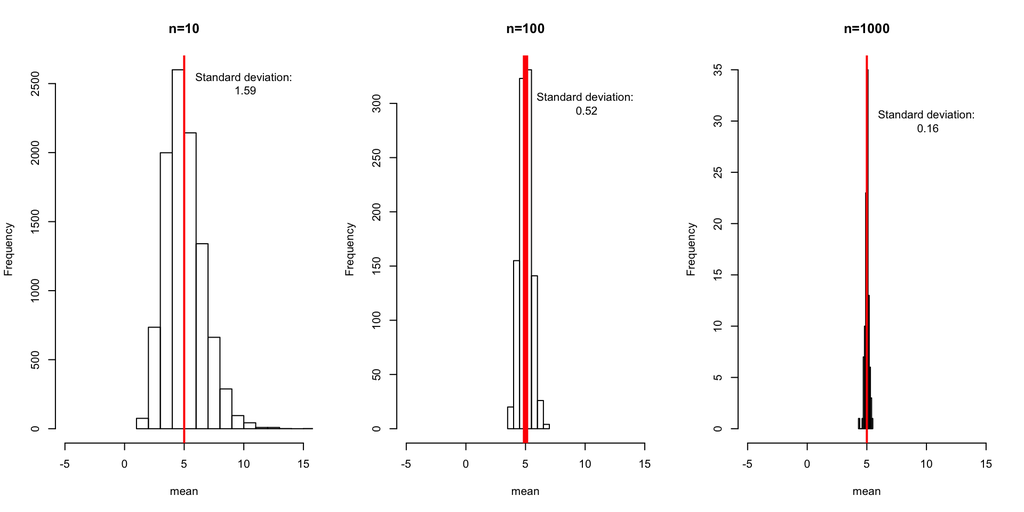

```r
par(mfrow=c(1,3))
hist(apply(random_data_10,1,mean),xlim=c(-5,15),main='n=10',xlab='mean')
abline(v = 5, col = "red",lwd = 2)
text(10,2500,labels=paste('Standard deviation:\n',round(sd(apply(random_data_10,1,mean)),digits = 2)))

hist(apply(random_data_100,1,mean),xlim=c(-5,15),main='n=100',xlab='mean')
abline(v = 5, col = "red",lwd = 5)
text(10,300,labels=paste('Standard deviation:\n',round(sd(apply(random_data_100,1,mean)),digits = 2)))

hist(apply(random_data_1000,1,mean),xlim=c(-5,15),main='n=1000',xlab='mean')
abline(v = 5, col = "red",lwd = 2)
text(10,30,labels=paste('Standard deviation:\n',round(sd(apply(random_data_1000,1,mean)),digits = 2)))
```

The Sample Mean is approximating to the Theoretical Mean as the `n` increasing which is indicated by the decreasing of the standard deviation.

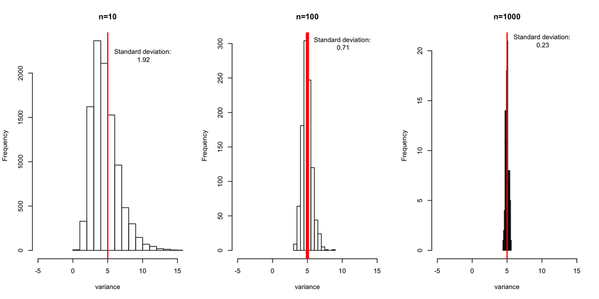

```r
par(mfrow=c(1,3))
hist(apply(random_data_10,1,sd),xlim=c(-5,15),main='n=10',xlab='variance')
abline(v = 5, col = "red",lwd = 2)
text(10,2200,labels=paste('Standard deviation:\n',round(sd(apply(random_data_10,1,sd)),digits = 2)))

hist(apply(random_data_100,1,sd),xlim=c(-5,15),main='n=100',xlab='variance')
abline(v = 5, col = "red",lwd = 5)
text(10,300,labels=paste('Standard deviation:\n',round(sd(apply(random_data_100,1,sd)),digits = 2)))

hist(apply(random_data_1000,1,sd),xlim=c(-5,15),main='n=1000',xlab='variance')
abline(v = 5, col = "red",lwd = 2)
text(10,21,labels=paste('Standard deviation:\n',round(sd(apply(random_data_1000,1,sd)),digits = 2)))
```

### Distribution

For the previouse part, we overlap the normal distribution with sample mean and sample variance as parameter to draw the Q-Q plot.

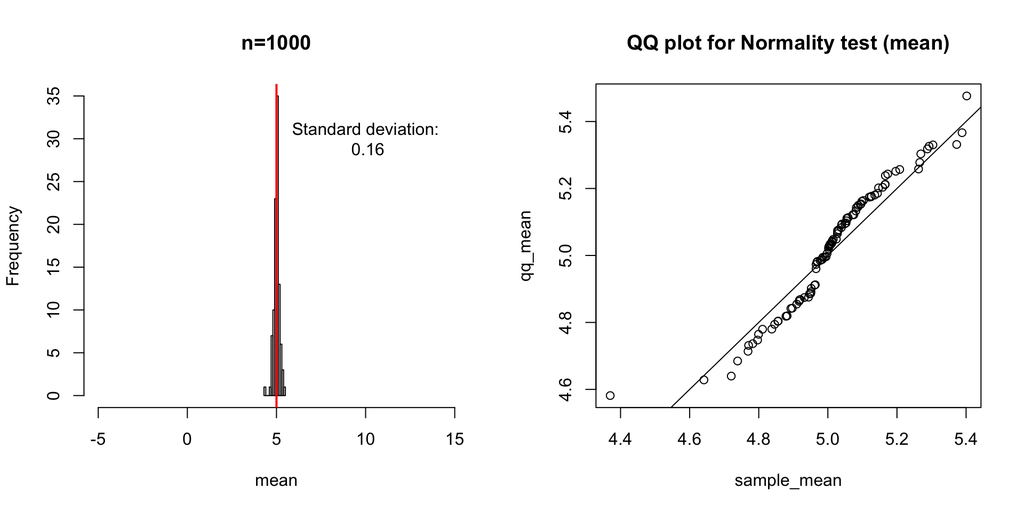

```r
#For Normality test of mean
par(mfrow=c(1,2))
sample_mean=apply(random_data_1000,1,mean)
mean_of_sample_mean=mean(sample_mean)
sd_of_sample_mean=sd(sample_mean)
qq_mean=rnorm(length(sample_mean),mean=mean_of_sample_mean,sd=sd_of_sample_mean)

hist(sample_mean,xlim=c(-5,15),main='n=1000',xlab='mean')
abline(v = 5, col = "red",lwd = 2)
text(10,30,labels=paste('Standard deviation:\n',round(sd(sample_mean),digits = 2)))

qqplot(sample_mean,qq_mean,main='QQ plot for Normality test (mean)')
abline(0,1)
```

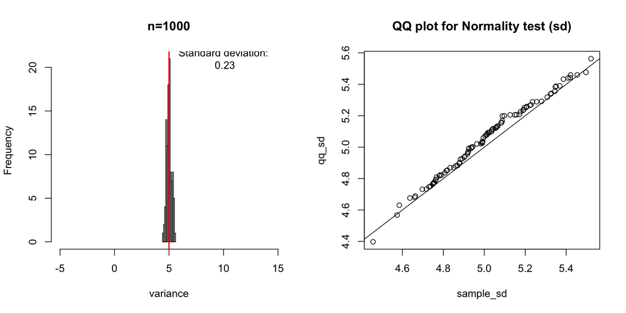

```r
#For Normality test of standard deviation
par(mfrow=c(1,2))
sample_sd=apply(random_data_1000,1,sd)
mean_of_sample_sd=mean(sample_sd)
sd_of_sample_sd=sd(sample_sd)
qq_sd=rnorm(length(sample_sd),mean=mean_of_sample_sd,sd=sd_of_sample_sd)

hist(apply(random_data_1000,1,sd),xlim=c(-5,15),main='n=1000',xlab='variance')
abline(v = 5, col = "red",lwd = 2)
text(10,21,labels=paste('Standard deviation:\n',round(sd(apply(random_data_1000,1,sd)),digits = 2)))

qqplot(sample_sd,qq_sd,main='QQ plot for Normality test (sd)')
abline(0,1)
```